# PVLDB

Bibliometric Analysis

Donatus Herre (SLUB Dresden)

2025-07-25

Branches: main / gh-pages

# Count Data

## Works

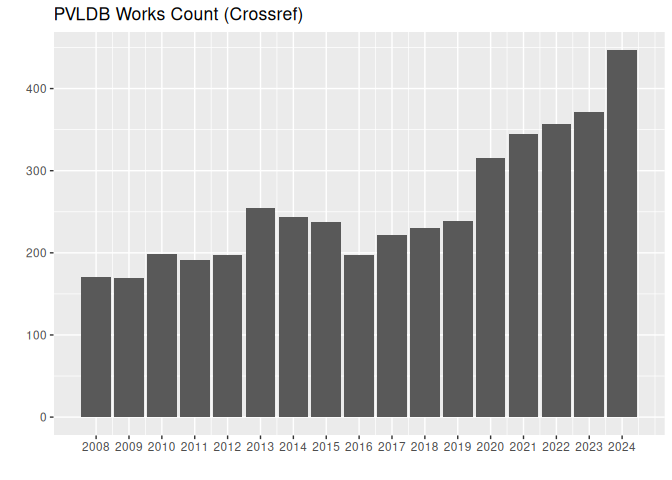

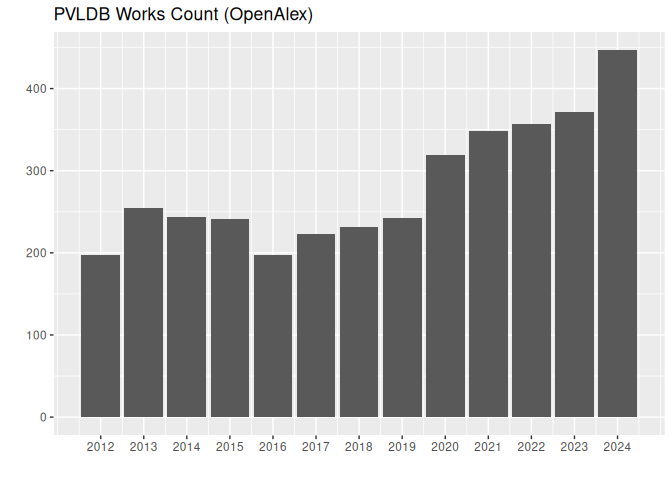

## Citations

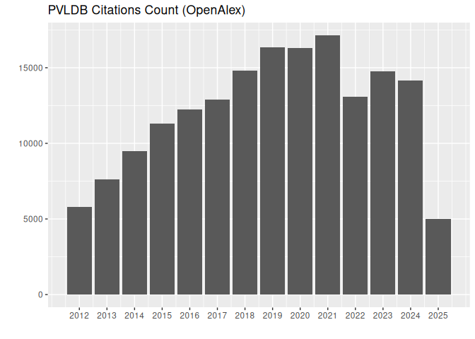

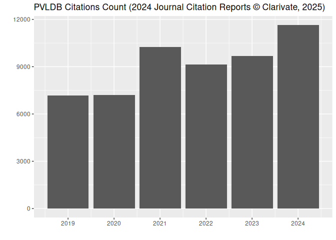

# Raw Data

- Crossref
  - prefixes (`10.14778`) [JSON, 137 B]
  - members (`5777`) [JSON, 4.72 KB] + members (`320`) [JSON, 23.78 KB]
  - journals (`2150-8097`) [JSON, 4.63 KB]
  - works (`filter=issn:2150-8097`) [JSON, 50.30 MB]
    - prefixes [JSON, 16 B]
    - members [JSON, 21 B]
    - dois [JSON, 130.62 KB]
    - dois-issue [JSON, 2.66 KB]
    - dois-article [JSON, 127.96 KB]
    - citation [JSON, 4.26 MB] (via OpenCitations)
      - dois [JSON, 1.94 MB]
      - issns [JSON, 60.03 KB]
      - count-issns [JSON, 72.76 KB]
      - count-issns [CSV, 225.93 KB] (enriched via OpenAlex)
      - year-types [JSON, 1.50 MB]
    - count-citation [JSON, 146.35 KB] (via OpenCitations)
    - reference [JSON, 2.99 MB]
      - dois [JSON, 1.13 MB]
      - issns [JSON, 41.45 KB]
      - count-issns [JSON, 50.14 KB]
      - count-issns [CSV, 153.98 KB] (enriched via OpenAlex)
      - year-types [JSON, 0.82 MB]
    - count-reference [JSON, 146.99 KB]
    - year-types [JSON, 100.93 KB]
- OpenAlex
  - sources (`S4210226185`) [JSON, 33.15 KB]

# Data Sources

- [Crossref API](https://api.crossref.org)
  - members
    - [320](https://api.crossref.org/members/320?mailto=bibliometrie@slub-dresden.de)
    - [5777](https://api.crossref.org/members/5777?mailto=bibliometrie@slub-dresden.de)
  - prefixes
    - [10.14778](https://api.crossref.org/prefixes/10.14778?mailto=bibliometrie@slub-dresden.de)
  - journals
    - [2150-8097](https://api.crossref.org/journals/2150-8097?mailto=bibliometrie@slub-dresden.de)
  - works
    - [filter=issn:2150-8097](https://api.crossref.org/works?filter=issn:2150-8097&mailto=bibliometrie@slub-dresden.de)
- [OpenCitations API](https://opencitations.net/index/coci/api/v1) (COCI)
  - citations
- [OpenAlex API](https://docs.openalex.org)
  - sources
    - [S4210226185](https://api.openalex.org/sources/S4210226185?mailto=bibliometrie@slub-dresden.de)
  - works
    - [filter=primary_location.source.id:S4210226185](https://api.openalex.org/works?filter=primary_location.source.id:S4210226185&mailto=bibliometrie@slub-dresden.de)

# Content Access

- VLDB Endowment
  - [PVLDB (Proceedings of the VLDB Endowment)](https://vldb.org/pvldb/)
- ACM DL > Collections > Hosted Content
  - [Proceedings of the VLDB Endowment](https://dl.acm.org/journal/pvldb)
- DBLP > Journals
  - [Proceedings of the VLDB Endowment](https://dblp.org/db/journals/pvldb/)

# Usage Terms

This document is licensed under a Creative Commons Attribution 4.0 International License.  
The raw data is made available under the CC0 1.0 Universal Public Domain Dedication.